# River Water Level Prediction

Andrew Chien

December 27, 2018

This notebook shows how River Water Level Data from Edmonton Canada can be filtered, sorted, and cleaned. Google Style Guide for R https://google.github.io/styleguide/Rguide.xml (UpperCamelCase for functions, period.separated for variable names) is adopted for this document.

Dataset Source: https://data.edmonton.ca/dataset/Water-Levels-and-Flows/cnsu-iagr

Note: the original dataset has chunks of missing data, rows with water level = -1. The data should be reported back on a 5 minute interval.

## Setup

Loads all of the libraries required

Source files, files and directories

```r
input.datafile <- "data/Water_Levels_and_Flows.csv"
data.directory <- "/data/"
projPath <- "C:/Users/andre/Desktop/WaterLevel"
fcnFile <- "/water_level_fcn.R"
source(paste(projPath, fcnFile, sep=""))
```

## Set Global variables for this program

Note: Edmonton “05DF001” `Edmonton` not used as it has two records with identical time stamp.

```r
station.name <- "atimCreek"
station.id <- "05EA012"
station.selectedmonth <- "2017-05"
station.selectedday <- "2017-05-01"
```

## Data Import

Read the large `water.dataset` into R Environment. Note: The loading will take a minute or two as the file is 500MB in size. Note: We will not run this code chunk unless we are changing the variables above.

## Data Tidying

This step is not needed as the dataset is already tidy (each column is a variable), each row is an observation.

## Data Transformation(DT)

### DT Part 1 - Narrow and Filter

Narrow, filter and store the selected River Water Level Station data(e.g. AtimCreek) into a dataset `station.data`

We run the `rm` command to remove the large `water.dataset` from memory.

Optional 2: If we would like to load the dataset from a previous run, run the following lines:

```r
working.directory <- getwd()
station.data <- read.csv(file=paste(working.directory, data.directory, station.name, ".csv", sep=""))
head(station.data)
```

```
##   X                 Row.ID Station.Number        Station.Description
## 1 1 05EA012-20170902223000        05EA012 Atim Creek at Century Road
## 2 2 05EA012-20171008062000        05EA012 Atim Creek at Century Road
## 3 3 05EA012-20171028193500        05EA012 Atim Creek at Century Road
## 4 4 05EA012-20170425194500        05EA012 Atim Creek at Century Road
## 5 5 05EA012-20170515225500        05EA012 Atim Creek at Century Road
## 6 6 05EA012-20171112215000        05EA012 Atim Creek at Century Road
##   Latitude Longitude       Station.Location          Date.and.Time
## 1 53.59033 -113.8856 (53.59033, -113.88557) 09/02/2017 10:30:00 PM
## 2 53.59033 -113.8856 (53.59033, -113.88557) 10/08/2017 06:20:00 AM
## 3 53.59033 -113.8856 (53.59033, -113.88557) 10/28/2017 07:35:00 PM
## 4 53.59033 -113.8856 (53.59033, -113.88557) 04/25/2017 07:45:00 PM
## 5 53.59033 -113.8856 (53.59033, -113.88557) 05/15/2017 10:55:00 PM
## 6 53.59033 -113.8856 (53.59033, -113.88557) 11/12/2017 09:50:00 PM
##   Water.Level..m. Water.Flow..cu.meter.per.sec.
## 1           8.542                        0.0969
## 2           8.661                        0.1807
## 3           8.654                        0.1693
## 4           8.931                        1.4975
## 5           8.733                        0.5837
## 6           8.661                       -1.0000
```

### DT - Part 2 - Select the columns needed

The commands below select only the Date and Time and Water level columns out of the `station.waterlevel` dataset.

```r
station.unsortedwaterlevel<-select(station.data, Date.and.Time, Water.Level..m.)
head(station.unsortedwaterlevel)
```

```
##            Date.and.Time Water.Level..m.
## 1 09/02/2017 10:30:00 PM           8.542
## 2 10/08/2017 06:20:00 AM           8.661
## 3 10/28/2017 07:35:00 PM           8.654
## 4 04/25/2017 07:45:00 PM           8.931
## 5 05/15/2017 10:55:00 PM           8.733
## 6 11/12/2017 09:50:00 PM           8.661
```

### DT - Part 3 - Sorting

```r
station.sortedwaterlevel <- station.unsortedwaterlevel[order(as.POSIXct(station.unsortedwaterlevel$Date.and.Time, format="%m/%d/%Y %I:%M:%S %p")), ]
write.csv(station.sortedwaterlevel, file=paste(working.directory, data.directory,station.name, "_sorted_water_level.csv", sep=""))
head(station.sortedwaterlevel)
```

```
##                Date.and.Time Water.Level..m.
## 22568 10/15/2016 08:00:00 AM           8.589
## 21995 10/15/2016 08:05:00 AM           8.589
## 29592 10/15/2016 08:10:00 AM           8.589
## 3944  10/15/2016 08:15:00 AM           8.589
## 27071 10/15/2016 08:20:00 AM           8.589
## 48380 10/15/2016 08:25:00 AM           8.589
```

### DT - Part 4 - Cleaning

In this portion, I will first see where there is incomplete data. To this I will use the `group_by()` to group the data into months and calculate the completeness statistic of the data.

##### Missing Data

31 Jan 2019: We will use the following code to detect if there is missing data in a particular month. We will group the water level info by month and summarise the number of records in each month and compare it against the number of supposed records per month.

We need to format the `station.sortedwaterlevel$Date.and.Time` which is of factor class into POSIXct class first.

```r
station.WLPOSIXct <- station.sortedwaterlevel
station.WLPOSIXct$Date.and.Time <- as.POSIXct(station.sortedwaterlevel$Date.and.Time, format="%m/%d/%Y %I:%M:%S %p")
head(station.WLPOSIXct)
```

```
##             Date.and.Time Water.Level..m.
## 22568 2016-10-15 08:00:00           8.589
## 21995 2016-10-15 08:05:00           8.589
## 29592 2016-10-15 08:10:00           8.589
## 3944  2016-10-15 08:15:00           8.589
## 27071 2016-10-15 08:20:00           8.589
## 48380 2016-10-15 08:25:00           8.589
```

Then we created a separate column using the substring `subtr()` function. The arguments `1,7` tells the function to only take the characters from 1 to 7 in the `Date.and.Time` column.

```r
station.WLPOSIXct$month.year <- substr(station.WLPOSIXct$Date.and.Time, 1, 7)
head(station.WLPOSIXct)
```

```
##             Date.and.Time Water.Level..m. month.year
## 22568 2016-10-15 08:00:00           8.589    2016-10
## 21995 2016-10-15 08:05:00           8.589    2016-10
## 29592 2016-10-15 08:10:00           8.589    2016-10
## 3944  2016-10-15 08:15:00           8.589    2016-10
## 27071 2016-10-15 08:20:00           8.589    2016-10
## 48380 2016-10-15 08:25:00           8.589    2016-10
```

Next we use the `groupy_by` and `summarise` with `mean, n()` functions to count the number of rows per month.  
As the water level data is reported by the telemetry station at 5 minutes intervals:  
For 31 days, if the data is complete, n = 8928  
For 30 days, n = 8640  
For 29 days, n = 8352  
For 28 days, n = 8064  
We store the results into a dataframe called `station.bymonth`. We also concatenate “-01” to the `month.year` column so we can calculate the no. of days in the month.

```r
station.WLPOSIXct$no.of.days <- days_in_month(as.Date(station.WLPOSIXct$Date, format ="%Y-%m-%d"))
station.bymonth <- station.WLPOSIXct %>%
  group_by(month.year) %>%
  summarise(mean = mean(station.WLPOSIXct$Water.Level..m.), n = n())
station.bymonth$mean <- NULL
names(station.bymonth) <- c("month.year", "no.of.rows")
station.bymonth$no.of.days <- days_in_month(as.Date(paste(station.bymonth$month.year, "-01", sep=""), format="%Y-%m-%d"))
station.bymonth$completeness <- station.bymonth$no.of.rows / (station.bymonth$no.of.days * 288) * 100
head(station.bymonth)
```

```
## # A tibble: 6 x 4
##   month.year no.of.rows no.of.days completeness
##   <chr>           <int>      <int>        <dbl>
## 1 2016-10          4515         31         50.6
## 2 2016-11          4176         30         48.3
## 3 2017-02          1009         28         12.5
## 4 2017-03          8417         31         94.3
## 5 2017-04          8618         30         99.7
## 6 2017-05          8928         31        100
```

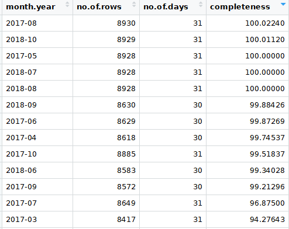

#### Taking just one month

We can use the `subset()` function to separate the data into months. A custom function called SubsetByMonth was written to do this repeatedly. The function takes two arguments a dataframe, and the year month in the “YYYY-MM” format.

```r
station.onemonth <- SubsetByMonth(station.WLPOSIXct,station.selectedmonth)
station.onemonth$month.year <- NULL
station.onemonth$no.of.days <- NULL
head(station.onemonth)
```

```
##             Date.and.Time Water.Level..m.
## 49203 2017-05-01 00:00:00           8.721
## 60542 2017-05-01 00:05:00           8.721
## 60049 2017-05-01 00:10:00           8.724
## 22289 2017-05-01 00:15:00           8.723
## 75005 2017-05-01 00:20:00           8.719
## 17951 2017-05-01 00:25:00           8.723
```

```r
tail(station.onemonth)
```

```
##             Date.and.Time Water.Level..m.
## 10021 2017-05-31 23:30:00           8.642
## 39593 2017-05-31 23:35:00           8.641
## 12292 2017-05-31 23:40:00           8.642
## 19009 2017-05-31 23:45:00           8.642
## 69556 2017-05-31 23:50:00           8.641
## 39788 2017-05-31 23:55:00           8.641
```

```r
str(station.onemonth)
```

```
## 'data.frame':    8928 obs. of  2 variables:
##  $ Date.and.Time  : POSIXct, format: "2017-05-01 00:00:00" "2017-05-01 00:05:00" ...
##  $ Water.Level..m.: num  8.72 8.72 8.72 8.72 8.72 ...
```

```r
write.csv(station.onemonth, file=paste(working.directory, data.directory,station.name,station.selectedmonth, ".csv", sep=""), row.names=FALSE)
```

18 Feb 19: The code below subsets the given dataframe into a day.

```r
station.oneday <- SubsetByDay(station.WLPOSIXct,station.selectedday)
head(station.oneday)
```

[output not shown]

```r
tail(station.oneday)
```

```
##             Date.and.Time Water.Level..m. month.year no.of.days
## 76591 2017-05-01 23:30:00           8.712    2017-05         31
## 24819 2017-05-01 23:35:00           8.713    2017-05         31
## 33975 2017-05-01 23:40:00           8.713    2017-05         31
## 34067 2017-05-01 23:45:00           8.714    2017-05         31
## 2774  2017-05-01 23:50:00           8.719    2017-05         31
## 69871 2017-05-01 23:55:00           8.715    2017-05         31
```

```r
str(station.oneday)
```

[output not shown]

```r
write.csv(station.oneday, file=paste(working.directory, data.directory,station.name,station.selectedday, ".csv", sep=""), row.names=FALSE)
```

#### Check for duplicated records

1 Feb 2019: Found out that even though the records for one month seems complete, take for example May 2017(100%, 8928 rows), some of the rows were duplicated. We will use the `duplicate()` function identify and remove duplicates. 1 Feb 2019 4pm Update: Found out that duplication was caused by incorrect format declaration during sorting i.e. duplicated records were caused by the loss of AM and PM characters.

```r
repeated.data <- station.onemonth$Date.and.Time[duplicated(station.onemonth$Date.and.Time)]
str(repeated.data)
```

```
##  'POSIXct' num(0)
##  - attr(*, "tzone")= chr ""
```

```r
head(repeated.data)
```

```
## POSIXct of length 0
```

From the results, no duplicate records were found.

#### Invalid values (-1)

After plotting the sorted Water Level data, I noticed that there are some “-1” or invalid values.

```r
station.negativewaterLevel <- filter(station.sortedwaterlevel, Water.Level..m. < 0 )
head(station.negativewaterLevel)
```

```
##            Date.and.Time Water.Level..m.
## 1 10/19/2016 01:10:00 AM              -1
## 2 10/19/2016 11:15:00 PM              -1
## 3 02/25/2017 11:00:00 AM              -1
## 4 03/02/2017 10:15:00 PM              -1
## 5 03/06/2017 09:10:00 AM              -1
## 6 03/08/2017 08:10:00 AM              -1
```

From the `station.negativewaterLevel` dataset, it seems that Nov 2016, Dec 2016, Jan 2017, May 2017, Dec 2017, Jan 2018, July 2018, August 2018 are the dates without -1 water level values.

For the conversion from the vector into a time series object we use the `ts()` function. The `ts()` function requires that the frequency and start time to be specified in year format. The start date is found at the first row of the `station.sortedwaterlevel` dataset. We will take that value and use that as a `begin.datetime` value. Note: the start year was previously manually calculated as *2016.7883652*

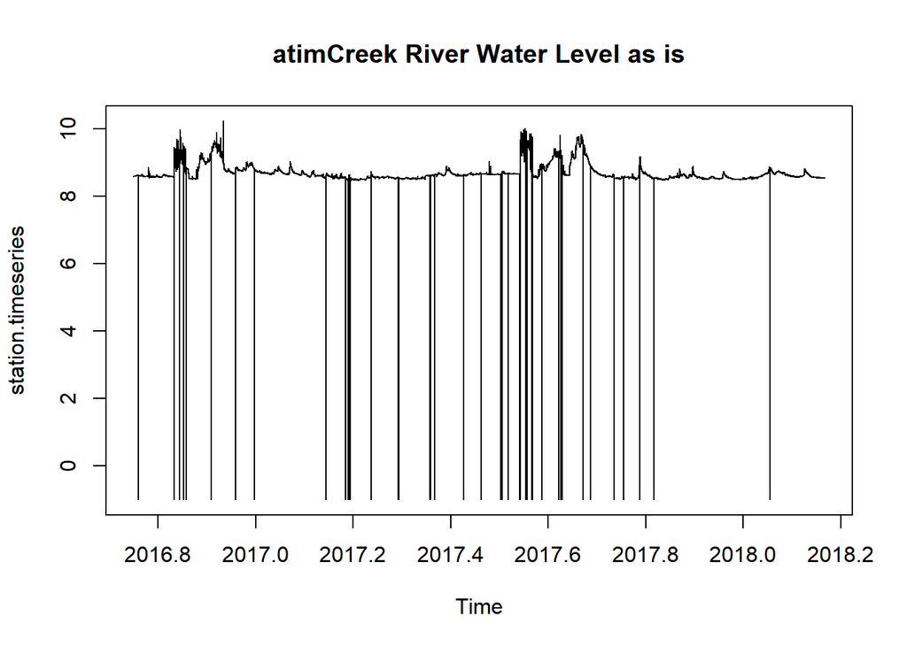

```r
station.timeseries <- select(station.WLPOSIXct, Water.Level..m.)
begin.datetime <- station.WLPOSIXct[1,1]
station.timeseries <-ts(station.timeseries, frequency = 12*24*365, start=c(as.yearmon(begin.datetime)))
plot.ts(station.timeseries)
title(main=paste(station.name,"River Water Level as is",sep=" "))
```

These values needs to be cleaned up and these samples removed. After cleaning, 98 samples with -1.000 water level was removed. Note: the removed samples has cause truncation in the dataset.

```r
station.cleanseries <- select(station.WLPOSIXct, Water.Level..m.)
station.cleanseries <- filter(station.cleanseries, Water.Level..m. > 0 )
station.cleantimeseries <-ts(station.cleanseries, frequency = 12*24*365, start=c(as.yearmon(begin.datetime)))
head(station.cleanseries)
```

```
##   Water.Level..m.
## 1           8.589
## 2           8.589
## 3           8.589
## 4           8.589
## 5           8.589
## 6           8.589
```

Next we can convert the cleaned station water level data into a time series for time series analysis in R. We will need select only the datetime sorted `Water.Level..m.` column

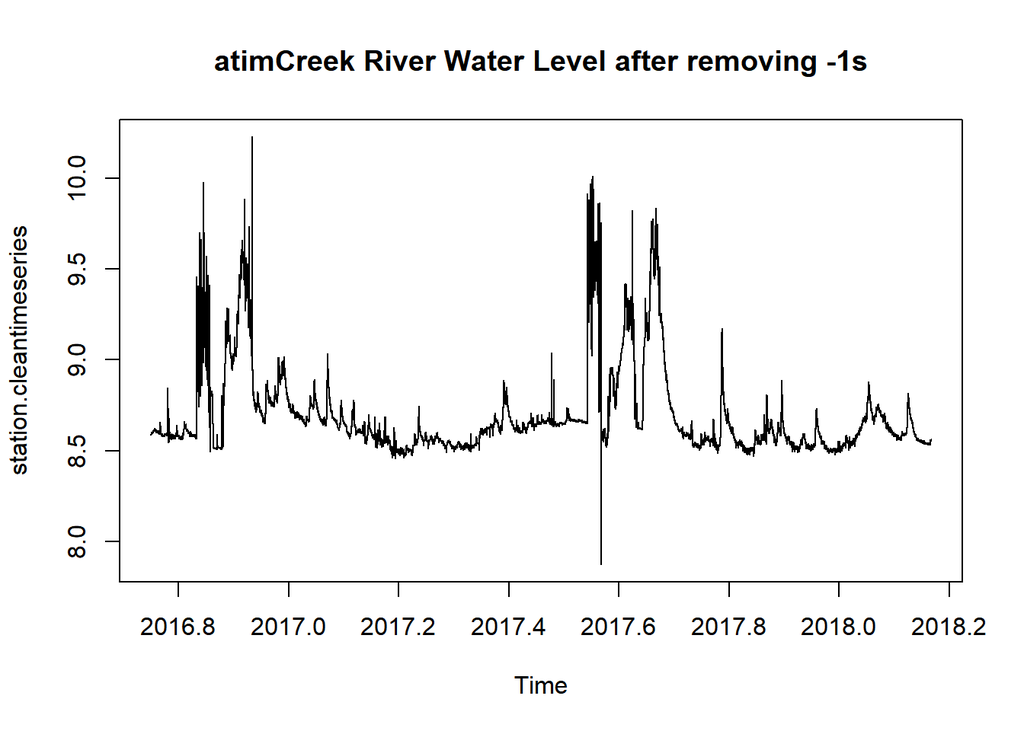

station.name

```r
plot.ts(station.cleantimeseries)
title(main=paste(station.name,"River Water Level after removing -1s",sep=" "))
```

Next we are going to select just one month of data and try to predict 5 days of water level using the one month of data. We will choose a month where there are no missing values. We will use the `station.sortedwaterlevel` dataset to see which dates have missing values. #END